# Sample Report - Data Science Capstone

Author

Published

January 9, 2024

## Introduction

### Paper Summaries

The paper titled "Linear Mixed-Effects Models for Within-Participant Psychology Experiments: An Introductory Tutorial and Free Graphical User Interface (LMMgui)" by David A. Magezi, published in 2015, introduces the concept of Linear Mixed-Effects Models (LMMs) within the context of psychology experiments. The author emphasizes the advantage of using LMMs when analyzing within-participant data, which is common in cognitive neuroscience and experimental psychology. The article explains how LMMs are favored over traditional methods such as ANOVA, particularly when dealing with data complexities like pseudoreplication. Explanatory variables in LMMs are categorized into fixed and random factors, which explain their roles and significance. The paper describes how LMMs handle both fixed-effects (main effects and interactions) and random-effects terms. Large focus is placed on the illustration of the use of LMMs through a hypothetical experiment, which demonstrates how to interpret the model results, while discussing the assumptions and limitations. Finally, the author introduces LMMgui, a graphical user interface which is designed to simplify the use of LMMs for experimental psychologists. This tool was developed for R’s lme4 package, in order to make LMMs more easily accessible.

The paper "Generalized Linear Mixed Models: A Practical Guide for Ecology and Evolution" by Bolker et al. provides an in-depth view on the application of Generalized Linear Mixed Models (GLMMs) in the realm of ecology and evolution. It focuses on the challenges that analyzing non-normal data that includes random effects can bring in these scenarios. Classical statistical methods often are not able to handle efficiently complex data types such as counts, proportions and binary outcomes, which, on the other hand, GLMMs are able to do. The estimation of GLMM parameters are discussed, noting that while several software packages exist for this purpose, the process can be challenging, even for statisticians. Multiple different estimation techniques are introduced, such as penalized quasilikelihood, Laplace approximations, and Markov chain Monte Carlo (MCMC) algorithms, and their advantages and limitations are explored. Large focus of the paper is directed towards the 'best practices' in data analysis when using GLMMs. Important factors include model selection, handling overdispersion, and dealing with issues such as boundary effects and calculation of degrees of freedom. The paper intends to serve as a resource for ecologists and evolutionary biologists that wish to apply GLMMs to their research, highlighting the complexities and providing solutions to common problems encountered in these analyses.

The paper, titled "Model selection in linear mixed effect models," by Heng Peng and Ying Lu, focuses on improving variable selection and parameter estimation in linear mixed effect models, which are both fundamental when analyzing longitudinal, panel, and cross-sectional data in various scientific fields. Their main contribution is a simple, iterative procedure for estimating and selecting both fixed and random effects in these models, utilizing the smoothly clipped absolute deviation (SCAD) penalty function. The shown method appears to be a consistent variable selection procedure with some oracle properties. The approach is then validated through simulation studies and real data analysis, which demonstrates its effectiveness and efficiency. However, the paper also acknowledges limitations, such as the method's reliance on specific conditions for asymptotic properties and potential computational challenges with high-dimensional data.

The paper "Random Effects Structure for Testing Interactions in Linear Mixed-Effects Models" by Dale J. Barr focuses on improving guidelines for using mixed-effects models in statistical analyses. The goal is to provide a more accurate method for testing interactions within these models. The paper critiques existing guidelines and proposes new ones, emphasizing the inclusion of random slopes for the highest-order combination of within-unit factors in interactions. The author uses Monte Carlo simulations to test these guidelines, demonstrating that neglecting critical random slopes can lead to unacceptably high Type I error rates, or the chance of a false rejection of the null hypothesis. The findings show that including the appropriate random slopes ensures better model performance. The paper significantly refines the approach to mixed-effects models, although it mainly focuses on interactions between categorical variables. The limitations include the scope of variable types and the specific conditions of the simulations used.

The paper, titled "Pymer4: Connecting R and Python for Linear Mixed Modeling" by Jolly (2018), discusses the development of Pymer4, a software tool designed to bridge R and Python for linear mixed modeling. It addresses the lack of similar, flexible packages in Python compared to R's lme4 package, highlighting the challenges Python users face in analyzing complex data structures like clustered, correlated, or repeatedly measured data. Pymer4 boasts a user-friendly interface, deep integration with scientific Python tools, and additional functionalities like significance testing. It also simplifies the process of conducting analyses that would typically require utilizing multiple R packages, by enhancing the efficiency of statistical modeling workflows within the Python ecosystem.

The paper titled, "A powerful and flexible linear mixed model framework for the analysis of relative quantification RT-PCR data" by Juan Pedro Steibel, et al. (2009), introduces a novel method for analyzing relative quantification RT-PCR data using a general linear mixed model, addressing the limitations of existing statistical methods and software in providing valid inferences across a wide range of experimental situations. This proposed approach offers more statistical power and flexibility compared to traditional methods like the comparative CT analysis and for analysis of a wider variety of situations. Through simulations using plasmode datasets and validation with experimental datasets, the authors demonstrate that their method yields more accurate and powerful results, especially beneficial for complex designs involving multiple experimental factors. The importance of correctly modeling all sources of variation is showcased by the model's capability to accommodate complex experimental designs and control for both biological and technical variation effectively.

## Methods

The common non-parametric regression model is $Y_i = m(X_i) + \varepsilon_i$, where $Y_i$ can be defined as the sum of the regression function value $m(x)$ for $X_i$. Here $m(x)$ is unknown and $\varepsilon_i$ some errors. With the help of this definition, we can create the estimation for local averaging i.e. $m(x)$ can be estimated with the product of $Y_i$ average and $X_i$ is near to $x$. In other words, this means that we are discovering the line through the data points with the help of surrounding data points. The estimation formula is printed below (R Core Team 2019):

$$M_n(x) = \sum_{i=1}^{n} W_n (X_i) Y_i \tag{1}$$
$W_n(x)$ is the sum of weights that belongs to all real numbers. Weights are positive numbers and small if $X_i$ is far from $x$.

$$y_i = \beta_0 + \beta_1 X_1 +\varepsilon_i$$

## Analysis and Results

### Data and Visualization

```r
# loading packages
library(tidyverse)
library(knitr)
library(ggthemes)
library(ggrepel)
library(dslabs)
```

```r
# Load Data
kable(head(murders))
```

| state | abb | region | population | total |
| --- | --- | --- | --- | --- |
| Alabama | AL | South | 4779736 | 135 |
| Alaska | AK | West | 710231 | 19 |
| Arizona | AZ | West | 6392017 | 232 |
| Arkansas | AR | South | 2915918 | 93 |
| California | CA | West | 37253956 | 1257 |
| Colorado | CO | West | 5029196 | 65 |

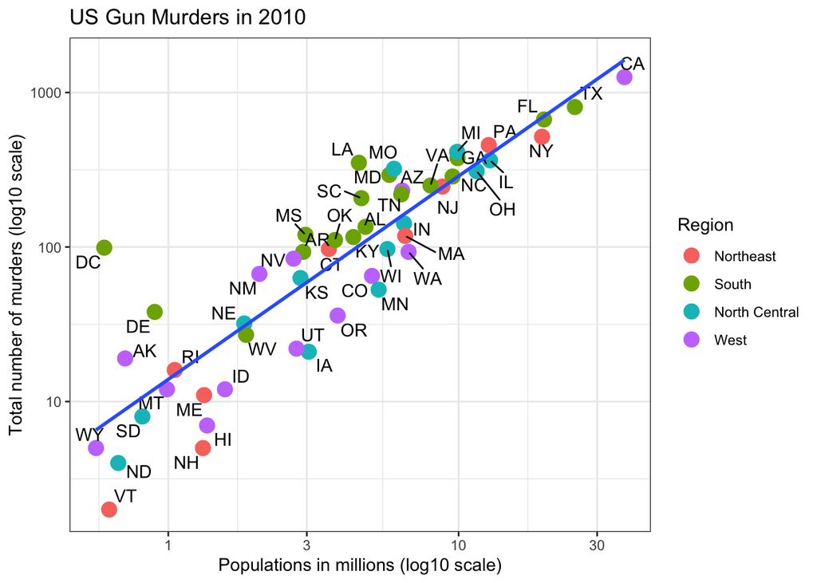

```r
ggplot1 = murders %>% ggplot(mapping = aes(x=population/10^6, y=total))

  ggplot1 + geom_point(aes(col=region), size = 4) +
  geom_text_repel(aes(label=abb)) +
  scale_x_log10() +
  scale_y_log10() +
  geom_smooth(formula = "y~x", method=lm,se = F)+
  xlab("Populations in millions (log10 scale)") +
  ylab("Total number of murders (log10 scale)") +
  ggtitle("US Gun Murders in 2010") +
  scale_color_discrete(name = "Region")+
      theme_bw()
```

## References

Bro, Rasmus, and Age K Smilde. 2014. “Principal Component Analysis.” *Analytical Methods* 6 (9): 2812–31.

Efromovich, S. 2008. *Nonparametric Curve Estimation: Methods, Theory, and Applications*. Springer Series in Statistics. Springer New York. https://books.google.com/books?id=mdoLBwAAQBAJ.

R Core Team. 2019. *R: A Language and Environment for Statistical Computing*. Vienna, Austria: R Foundation for Statistical Computing. https://www.R-project.org.

Wang, Ming. 2014. “Generalized Estimating Equations in Longitudinal Data Analysis: A Review and Recent Developments.” *Advances in Statistics* 2014.